# Notebook

## The SIR model

In this project I will deepen the behaviour of the SIR model and I will try to propose some techniques to mitigate the effect of the spread in the graph using 4 different immunization strategies.

```python
import numpy as np
import seaborn as sns
import matplotlib.pyplot as plt
from collections import Counter
import networkx as nx
import operator
import itertools
from collections import OrderedDict
from cycler import cycler
```

## Part 1: Barabasi - Albert Graph

As frist I generate the Barabasi Graph, these are Scalee - Free graph, hence is a graph whose degree distribution asymptotically follows a power law. The Barabási–Albert model assumes that the probability that a node attaches to another node is proportional to the degree of the node, in fact this kind of graph is composed by hubs (nodes having high degree that exceed the average degree) followed by smaller degree nodes, each followed by others smaller degree nodes and so on. This property is called preferential attachment, so that a vertex that already has a large number of edges connecting it to other vertices will tend to attract still more edges. That's the reason why this graph is used in social networks, where heavily linked nodes represent well-known people with lots of relations and so when a newcomer enters the community, he is more likely to become acquainted with one of those more visible people rather than with a relative unknown.

Here I built a Barabasi - Albert graph, that start with 1000 nodes having 4 edges and then step by step it adds edges to the nodes having more edges, so that with a probability proportional number of edges. As first I check that it's connected. And then we can see the histogram representing the degree distribution. For the preferential attachment we can see that the most part of nodes few edges and only few has more then 10 nodes.

```python
N=1000
g = nx.barabasi_albert_graph(N,4)
nx.is_connected(g)
```

```
True
```

```
C:\Users\Paola Anna Puglisi\Anaconda3\lib\site-packages\statsmodels\nonparametric\kdetools.py:20: VisibleDeprecationWarning: using a non-integer number instead of an integer will result in an error in the future
  y = X[:m/2+1] + np.r_[0,X[m/2+1:],0]*1j
```

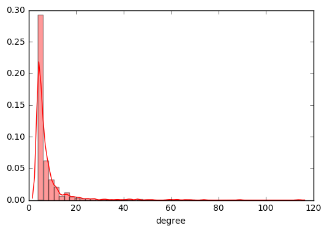

```python
# Distribution of the degree of the nodes in the graph.

sns.distplot(list(g.degree().values()), axlabel='degree' )
plt.show()
```

# Exercise 1.2

Now we can built a function that simulate a SIR epidemic process on the graph. It takes in input the already created graph, parameter beta and parametes mu. Beta is the probability of taking the desease, mu is the probability of be recovered after the disease, hence that nodes cannot take the disease anymore. As first all nodes are considered as susceptible, then it chooses at random a node and it infect this, in fact it's added to the list of infected people (I). Now with a random probability (taken by an uniform) less then beta it could infect his neighbors still susceptible that become infected. The same happens for the recovered list, in fact the function throws a random a probability and if this is less than mu this nodes could be recovered. At the end the function returns a dictionary having as key the Time, Susceptible nodes, Infected nodes, Recovered nodes, and 'StoI' and 'ItoR' for the two lists of nodes passed from susceptible to infected and from infected to recovered.

```python
class SIR:
    def __init__(self, g, beta, mu):
        self.g = g
        self.beta = beta
        self.mu = mu

    def run(self, seed=[], num_steps = 1, sentinels = []):
        if len(seed) == 0:

            seed = [np.random.choice(self.g.nodes())]

        I_set = set(seed)
        S_set = set(self.g.nodes()).difference(I_set)
        R_set = set()

        t = 0

        StoI = set(seed)
        ItoR = set()

        while len(I_set) > 0:
            for i in I_set.copy():
                for s in set(self.g.neighbors(i)).intersection(S_set).copy():
                    if np.random.uniform() < self.beta:
                        S_set.remove(s)
                        I_set.add(s)
                        StoI.add(s)


                if np.random.uniform() < self.mu:
                    I_set.remove(i)
                    R_set.add(i)
                    ItoR.add(i)

            t += 1
            if t % num_steps == 0 or len(I_set) == 0:
                yield({'t': t, 'S':S_set, 'I':I_set, 'R':R_set, 'StoI':StoI, 'ItoR':ItoR})
```

For example below we can see the epidemic curve for a single realization of the epidemic, with Beta = 0.4 and mu=0.2.

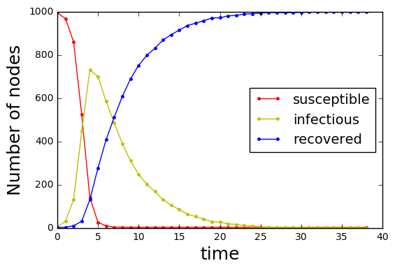

```python
sir= SIR(g, beta = 0.4, mu = 0.2)
plt.plot([ (len(status['S']), len(status['I']),len(status['R'])) for status in sir.run()], '.-')
plt.xlabel('time', fontsize=18)
plt.ylabel('Number of nodes', fontsize=18)
plt.legend(['susceptible', 'infectious', 'recovered'], fontsize=14, loc=7)
plt.show()
```

Now, setting a vector for the parameters beta and mu, I can simulate an epidemic and then choose values of parameters that recover a given thresold of people. Hence I simulate 100 epidemic for each couple of parameter and at the end I save the ratio between the number of recovered node at the end of the process and the number of node N. Let's suppose I want an epidemic that take of with high probability, reaching most of the nodes, in this case I have to choose the couple beta = 0.6 and mu = 0.2.

```python
betas = [0.2, 0.4, 0.6]
mus = [0.2, 0.4, 0.6]
results = {}

for b in betas:
    for m in mus:
        final_r = []
        sir = SIR(g, beta = b, mu = m)
        for i in range(0,100):

            res = [r for r in sir.run()]
            final_r.append(len(res[len(res)-1].get('R')))

        results[(b, m)] = np.mean([i/N for i in final_r])
```

```python
print(results)
```

```
{(0.2, 0.4): 0.73343434343434355, (0.4, 0.2): 0.98857575757575744, (0.2, 0.2): 0.90175757575757587, (0.2, 0.6): 0.59305050505050505, (0.6, 0.2): 0.99990909090909086, (0.4, 0.6): 0.84698989898989885, (0.6, 0.6): 0.98713131313131308, (0.4, 0.4): 0.98086868686868678, (0.6, 0.4): 0.99913131313131309}
```

Below we can see that, starting a simulation of 100 realization with the chosen parameters, the boxplot of the results is obviously concentrated in 1, that's why we have chosen two parameters that infect almost the nodes so the ratio values of recovered is 1 for the most part of simulation.

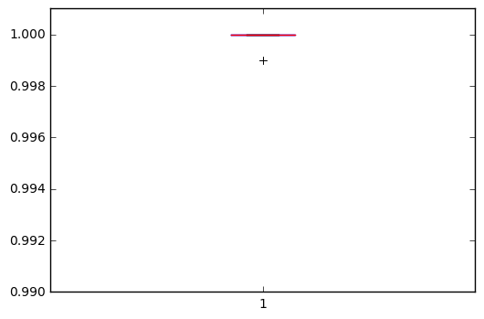

```python
resultsSIR = []
final_r = []
for i in range(0,100):
    sir = SIR(g, beta = 0.6, mu = 0.2)
    res = [r for r in sir.run()]
    final_r.append(len(res[len(res)-1].get('R')))
resultsSIR.append([i/len(g.nodes()) for i in final_r])


plt.boxplot(resultsSIR)
plt.ylim(ymin=0.99,ymax=1.001)
plt.show()
```

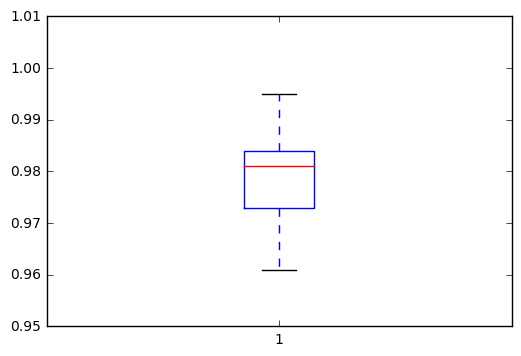

```python
resultsSIR = []
final_r = []
for i in range(0,100):
    sir = SIR(g, beta = 0.2, mu = 0.2)
    res = [r for r in sir.run()]
    final_r.append(len(res[len(res)-1].get('R')))
resultsSIR.append([i/len(g.nodes()) for i in final_r])


plt.boxplot(resultsSIR)
plt.ylim(ymin=0.95,ymax=1.01)
plt.show()
```

# Ex 1.3

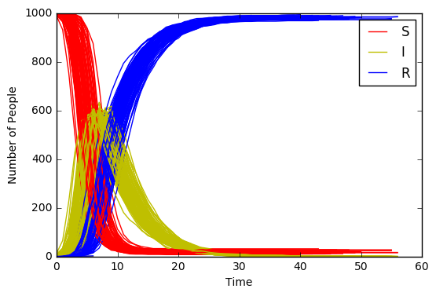

```python
time, peack, time1=[], [], []
for i in range(0,100):
    sir= SIR(g, beta = 0.2, mu = 0.2)
    picco=[]

    for r in sir.run(num_steps=1):

        picco.append(len(r['I']))
        time1.append(r['t'])

    peack.append(max(picco))

    time.append(time1[max(range(len(picco)), key = lambda x: picco[x])])

    plt.rc("axes", prop_cycle=(cycler("color", ['r','y','b'])))
    plt.plot([[len(r['S']), len(r['I']), len(r['R'])] for r in sir.run(num_steps=1)])
plt.legend(['S', 'I', 'R'])
plt.xlabel("Time")
plt.ylabel("Number of People")
plt.show()
```

Here we can see the probability distribution of the peack times for the epidemic. The overall distribution is placed between 0.1 and 0.15, it means that the maximum attack rate happens in the first fifth of the simulations' time.

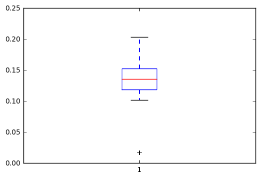

```python
time= [time[i]/ max(time1) for i in range(0, len(time))]
plt.boxplot(time)
plt.show()
```

# Ex 2.1

Consider a given initial fraction r of randomly chosen "immunized" nodes, this means that for each loop of the function there is an r percent of the nodes that cannot be infected, so the epidemic spread in the remaining part of the population. In fact at the end of the simulation the result gives a number of recovered nodes less than the total number of these at least for the r percent of the population. This means that the maximum rate of population infected, and so recovered, is 1-r %.

## Ex 2.2

Because of the wide variability in the degree of the nodes, there's need to find immunization strategies. Different strategies already exists, such that strategies based on targeting members of the network according to their connectivity rather than random immunization of the network. In circumstances then where vaccines are scarce, efficient immunization strategies become necessary to preventing more infectious. In this point I modified the Sir function to apply the first strategy immunization: randomly chosen "immunized" nodes. In fact the only difference is that it chooses some random nodes to "vaccinate" so that these cannot be infected.

```python
class SIRimm:
    def __init__(self, g, r, beta, mu):
        self.g = g
        self.beta = beta
        self.mu = mu
        self.r = r
    def run(self, seed=[],  num_steps = 1, sane = []):

        sane= np.random.choice(len(self.g.nodes()), int(len(self.g.nodes())*self.r), replace=False)
        if len(seed) == 0:
            seed = [np.random.choice(list(set(self.g.nodes()).difference(sane)))]

        I_set = set(seed)
        S_set = set(self.g.nodes()).difference(I_set)
        R_set = set()

        t = 0

        StoI = set(seed)
        ItoR = set()

        while len(I_set) > 0:
            for i in I_set.copy():
                for s in set(self.g.neighbors(i)).difference(sane).intersection(S_set).copy():
                    if np.random.uniform() < self.beta :
                        S_set.remove(s)
                        I_set.add(s)
                        StoI.add(s)


                if np.random.uniform() < self.mu:
                    I_set.remove(i)
                    R_set.add(i)
                    ItoR.add(i)

            t += 1
            if t % num_steps == 0 or len(I_set) == 0:
                yield({'t': t, 'S':S_set, 'I':I_set, 'R':R_set, 'StoI':StoI, 'ItoR':ItoR})
```

```python
results = {}
rvec=[0.01, 0.1, 0.15, 0.2, 0.3, 0.4, 0.5, 0.6, 0.7, 0.8, 0.9]
for r1 in rvec:
        final_r = []
        for i in range(0,100):
            sir = SIRimm(g, r=r1, beta = 0.2, mu = 0.2)
            res = [k for k in sir.run()]
            final_r.append(len(res[len(res)-1].get('R')))
        results[r1] =  np.mean(final_r)
```

```python
results
```

```
{0.01: 834.13999999999999,
 0.1: 810.19000000000005,
 0.15: 725.64999999999998,
 0.2: 681.97000000000003,
 0.3: 507.50999999999999,
 0.4: 415.89999999999998,
 0.5: 304.56,
 0.6: 178.69,
 0.7: 73.480000000000004,
 0.8: 13.91,
 0.9: 2.21}
```

In the graphic below, we can see that the more is the coverage the less is the average of recovered nodes. It is obviously because the bigger is r the more are the vaccines that you have, so that the bigger is the coverage.

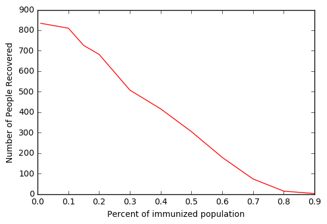

```python
plt.plot(*zip(*sorted(results.items())))
plt.xlabel("Percent of immunized population")
plt.ylabel("Number of People Recovered")
plt.show()
```

# Ex 2.3

Erdős and Rényi studied a model of growth for graphs in which, at each step, two nodes are chosen uniformly at random and a link is inserted between them with probability p. For this reasons it could happens that the graph results not connected. The properties of these random graphs are different from the properties found in scale-free networks, for example there isn't peferential attachment, so that the ER graph is less dense than the BA graph. For this reason I built a graph ER with the same density as the BA graph, to make more fair the comparisons. I also added a while loop that try to build ER graph until it is connected.

```python
f= nx.erdos_renyi_graph(N, nx.density(g), seed=None, directed=False)
while nx.is_connected(f)==False:
    f= nx.erdos_renyi_graph(N, nx.density(g), seed=None, directed=False)
```

```python
nx.is_connected(f)
```

```
True
```

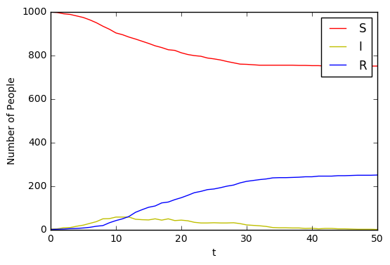

```python
sir = SIRimm(f, r=0.6, beta = 0.2, mu = 0.2)
plt.plot([[len(r['S']), len(r['I']), len(r['R'])] for r in sir.run(num_steps=1)])
plt.legend(['S', 'I', 'R'])
plt.xlabel("t")
plt.ylabel("Number of People")
plt.show()
```

Below we can observe the graphic of the percentage of the recovered nodes for the two graphs.

```python
resultsER = {}
rvec=[0.01, 0.1, 0.15, 0.2, 0.3, 0.4, 0.5, 0.6, 0.7, 0.8, 0.9]
for r1 in rvec:
        final_r=[]
        for i in range(1,100):
            sir = SIRimm(f, r=r1, beta = 0.2, mu = 0.2)
            res = [k for k in sir.run()]
            final_r.append(len(res[len(res)-1].get('R')))

        resultsER[r1] =   np.mean(final_r)
```

```python
resultsER
```

```
{0.01: 871.29292929292933,
 0.1: 859.09090909090912,
 0.15: 772.40404040404042,
 0.2: 745.89898989898995,
 0.3: 578.41414141414145,
 0.4: 434.78787878787881,
 0.5: 298.28282828282829,
 0.6: 196.27272727272728,
 0.7: 59.656565656565654,
 0.8: 7.2525252525252526,
 0.9: 1.6464646464646464}
```

```python
results
```

```
{0.01: 834.13999999999999,
 0.1: 810.19000000000005,
 0.15: 725.64999999999998,
 0.2: 681.97000000000003,
 0.3: 507.50999999999999,
 0.4: 415.89999999999998,
 0.5: 304.56,
 0.6: 178.69,
 0.7: 73.480000000000004,
 0.8: 13.91,
 0.9: 2.21}
```

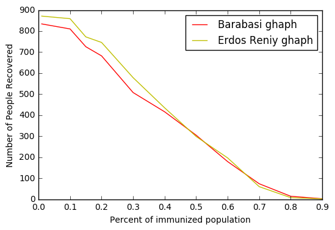

```python
plt.plot(*zip(*sorted(results.items())), *zip(*sorted(resultsER.items())))
plt.legend( ['Barabasi ghaph', 'Erdos Reniy ghaph'])
plt.xlabel("Percent of immunized population")
plt.ylabel("Number of People Recovered")
plt.show()
```

# Ex. 3.1

A common approach for targeted immunization studies in scale-free networks is to target the highest degree nodes for immunization. These nodes are the most highly connected in the network, making them more likely to spread the contagion if infected. Immunizing this segment of the network can drastically reduce the impact of the disease on the network.

Here I modified the SIR function in two ways: the first immunizes the first r% of nodes having higher degree (ordered), the second immunizes the first r% of nodes having higher betweenes centrality. These procedure are almost the same because the nodes with higher degree are more central. But betweenness centrality quantifies the number of times a node acts as a bridge along the shortest path between two other nodes. In fact this measure was introduced as a measure for quantifying the control of a human on the communication between other humans in a social network. Vertices that have a high probability to occur on a randomly chosen shortest path between two randomly chosen vertices have a high betweenness.

```python
class SIRvacc:
    def __init__(self, g, r, beta, mu):
        self.g = g
        self.beta = beta
        self.mu = mu
        self.r = r
    def run(self, seed=[],  num_steps = 1, sane = []):

        perc=self.r
        begin=len(self.g.nodes())-(len(self.g.nodes())*perc)
        end=len(self.g.nodes())

        c = dict(Counter(self.g.degree() ))
        sorted_dictionary = OrderedDict(sorted(c.items(), key=lambda v: v[1], reverse=False))
        vaccinated=list(sorted_dictionary)[int(begin):int(end)]

        if len(seed) == 0:
            seed = [np.random.choice(list(set(self.g.nodes()).difference(vaccinated)))]

            I_set = set(seed)
            S_set = set(self.g.nodes()).difference(I_set)
            R_set = set()

            t = 0

            StoI = set(seed)
            ItoR = set()

            while len(I_set) > 0:
                for i in I_set.copy():
                    for s in set(self.g.neighbors(i)).difference(vaccinated).intersection(S_set).copy():
                        if np.random.uniform() < self.beta :
                            S_set.remove(s)
                            I_set.add(s)
                            StoI.add(s)

                    if np.random.uniform() < self.mu:
                        I_set.remove(i)
                        R_set.add(i)
                        ItoR.add(i)

                t += 1
                if t % num_steps == 0 or len(I_set) == 0:
                    yield({'t': t, 'S':S_set, 'I':I_set, 'R':R_set, 'StoI':StoI, 'ItoR':ItoR})
```

```python
class SIRcentrality:
    def __init__(self, g, r, centrality, beta, mu):
        self.g = g
        self.beta = beta
        self.mu = mu
        self.r = r
        self.centr= centrality
    def run(self, seed=[],  num_steps = 1, sane = []):

        perc=self.r

        vaccinated=self.centr[0:int(self.r*len(self.centr))]

        if len(seed) == 0:
            seed = [np.random.choice(list(set(self.g.nodes()).difference(vaccinated)))]

            I_set = set(seed)
            S_set = set(self.g.nodes()).difference(I_set)
            R_set = set()

            t = 0

            StoI = set(seed)
            ItoR = set()

            while len(I_set) > 0:
                for i in I_set.copy():
                    for s in set(self.g.neighbors(i)).difference(vaccinated).intersection(S_set).copy():
                        if np.random.uniform() < self.beta :
                            S_set.remove(s)
                            I_set.add(s)
                            StoI.add(s)

                    if np.random.uniform() < self.mu:
                        I_set.remove(i)
                        R_set.add(i)
                        ItoR.add(i)

                t += 1
                if t % num_steps == 0 or len(I_set) == 0:
                    yield({'t': t, 'S':S_set, 'I':I_set, 'R':R_set, 'StoI':StoI, 'ItoR':ItoR})
```

Here the recovered rate for the values of r in the two cases, note that in the case of Betweenness I add an input at the function the list of nodes ordered based on the values of the betweenness.

```python
#centrality
a=sorted(nx.betweenness_centrality(g).items(), key= lambda x: x[1], reverse=True)
a1=[(i[0])  for i in a]

results2centr = {}
rvec=[0.01, 0.05, 0.1, 0.15, 0.2, 0.3, 0.4, 0.5, 0.6, 0.7, 0.8, 0.9]
for r1 in rvec:
        final_r=[]
        for i in range(1,100):
            sir = SIRcentrality(g, r=r1, centrality=a1, beta = 0.2, mu = 0.2)
            res = [k for k in sir.run()]
            final_r.append(len(res[len(res)-1].get('R')))

        results2centr[r1] =   np.mean(final_r)
```

```python
#degree
results2 = {}
rvec=[0.01, 0.05, 0.1, 0.15, 0.2, 0.3, 0.4, 0.5, 0.6, 0.7, 0.8, 0.9]
for r1 in rvec:
        final_r=[]
        for i in range(1,100):
            sir = SIRvacc(g, r=r1, beta = 0.2, mu = 0.2)
            res = [k for k in sir.run()]
            final_r.append(len(res[len(res)-1].get('R')))

        results2[r1] =   np.mean(final_r)
```

```python
results2
```

```
{0.01: 852.46464646464642,
 0.05: 700.43434343434342,
 0.1: 512.12121212121212,
 0.15: 331.38383838383839,
 0.2: 107.66666666666667,
 0.3: 4.6969696969696972,
 0.4: 2.2929292929292928,
 0.5: 1.3636363636363635,
 0.6: 1.101010101010101,
 0.7: 1.0,
 0.8: 1.0,
 0.9: 1.0}
```

```python
results2centr
```

```
{0.01: 871.41414141414145,
 0.05: 700.30303030303025,
 0.1: 499.82828282828285,
 0.15: 399.75757575757575,
 0.2: 136.14141414141415,
 0.3: 10.363636363636363,
 0.4: 2.8181818181818183,
 0.5: 1.3737373737373737,
 0.6: 1.1313131313131313,
 0.7: 1.0404040404040404,
 0.8: 1.0101010101010102,
 0.9: 1.0}
```

The graphic below is interesting because it is clear a big improvement on the recovered nodes. In fact with a better immunization strategy it's easier to have a lower spread of the disease. The random immunization takes at random the nodes to immunize, so in the case of limited budget of vaccination there's need of a strategy to apply vaccines to the nodes that could slow down the spread of disease. Vaccinate the people having more "social power" in terms of connection, seems to be the best strategy because you have an higher probability of reaching more people, so if you immunize that nodes you prevents from the disease the nodes linked to him.

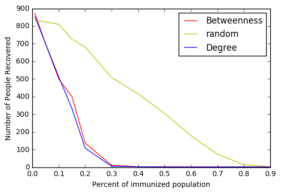

```python
plt.plot(*zip(*sorted(results2centr.items())),*zip(*sorted(results.items())), *zip(*sorted(results2.items())))
plt.legend(['Betweenness', 'Random', 'Degree'])
plt.xlabel("Percent of immunized population")
plt.ylabel("Number of People Recovered")
plt.show()
```

# Ex 3.2

A more practical situation is that you don't know the entire graph. We don't know anything about the nodes and their degree. So I decided to simulate SIR function 100 times and saving the nodes that get the diseas for each time.

```python
class SIRsent:
    def __init__(self, g, beta, mu):
        self.g = g
        self.beta = beta
        self.mu = mu

    def run(self, seed=[], num_steps = 1, sentinels = []):
        if len(seed) == 0:
            seed = [np.random.choice(self.g.nodes())]

        I_set = set(seed)
        S_set = set(self.g.nodes()).difference(I_set)
        R_set = set()

        t = 0

        StoI = set(seed)
        ItoR = set()

        sentinels_t = {}
        for sen in sentinels:
            sentinels_t[sen] = 0

        while len(I_set) > 0:
            for i in I_set.copy():
                for s in set(self.g.neighbors(i)).intersection(S_set).copy():
                    if np.random.uniform() < self.beta:
                        S_set.remove(s)
                        I_set.add(s)
                        StoI.add(s)


                        if sentinels_t.get(s) != None:
                            sentinels_t[s] = t


                if np.random.uniform() < self.mu:
                    I_set.remove(i)
                    R_set.add(i)
                    ItoR.add(i)

            t += 1
            if t % num_steps == 0 or len(I_set) == 0:
                yield({'t': t, 'S':S_set, 'I':I_set, 'R':R_set, 'StoI':StoI, 'ItoR':ItoR, 'sentinels': sentinels_t})
```

```python
sentinels = g.nodes()
sir_sentinels = SIRsent(g, beta = 0.2, mu = 0.2)
sentinels_results = []

for i in range(0,100):
    status_sentinels = [status for status in sir_sentinels.run(sentinels=sentinels)]

    sentinels_results.append(status_sentinels[len(status_sentinels)-1].get('sentinels'))
```

"sentinels_results" is a dictionary having as key the nodes and as value the time in which that nodes get the disease in that simulation. I decided to apply the mean for each nodes of their values (sentnew) and in the end I ordered these dict based on the lower time of getting the disease.

```python
sentnew={}
for i in sentinels_results[0].keys():
    sentnew[i]=[]
    for j in range(0,len(sentinels_results)):
        sentnew[i].append(sentinels_results[j][i])
for k in sentnew.keys():
    sentnew[k]=np.mean(sentnew[k])
sentnew=OrderedDict(sorted(sentnew.items(), key=lambda v: v[1], reverse=False))
```

```python
sentnew
```

```
OrderedDict([(5, 3.6099999999999999),
             (6, 3.6499999999999999),
             (4, 3.77),
             (2, 3.8700000000000001),
             (7, 3.9199999999999999),
             (11, 3.9500000000000002),
             (15, 4.0099999999999998),
             (1, 4.04),
             (20, 4.0999999999999996),
             (10, 4.1799999999999997),
             (21, 4.1900000000000004),
             (14, 4.2000000000000002),
             (27, 4.2000000000000002),
             (8, 4.2599999999999998),
             (31, 4.2999999999999998),
             (51, 4.3099999999999996),
             (32, 4.3300000000000001),
             (40, 4.3600000000000003),
             (9, 4.3799999999999999),
             (18, 4.3899999999999997),
             (24, 4.4000000000000004),
             (16, 4.4400000000000004),
             (12, 4.46),
             (87, 4.4699999999999998),
             (62, 4.5),
             (36, 4.5999999999999996),
             (13, 4.6200000000000001),
             (29, 4.6200000000000001),
             (42, 4.6200000000000001),
             (60, 4.6399999999999997),
             (25, 4.6500000000000004),
             (47, 4.6600000000000001),
             (82, 4.6900000000000004),
             (66, 4.7000000000000002),
             (17, 4.7199999999999998),
             (68, 4.7300000000000004),
             (28, 4.7699999999999996),
             (37, 4.7699999999999996),
             (54, 4.7699999999999996),
             (22, 4.79),
```

[output cut: 945 more lines]

```
             (823, 7.2300000000000004),
             (648, 7.2400000000000002),
             (768, 7.2400000000000002),
             (567, 7.25),
             (643, 7.25),
             (983, 7.3099999999999996),
             (920, 7.3300000000000001),
             (933, 7.3899999999999997),
             (806, 7.4000000000000004),
             (843, 7.4100000000000001),
             (896, 7.4100000000000001),
             (978, 7.4100000000000001),
             (974, 7.4299999999999997),
             (995, 7.4400000000000004),
             (553, 7.46)])
```

Now I create the function "SIRsent1" that takes in input also the just computed ordered dict. In this way, for each r, it immunize the first r*n nodes of the sentnew dict. Hence as first it immunize the nodes that in the previous simulation get the disease before the other nodes. This is a valid strategy, but not as the target one. So it seems more important to immunize based on the degree of a node, than the time of getting the disease that is also better than the random immunization.

```python
class SIRsent1:
    def __init__(self, g, r, sentinels, beta, mu):
        self.g = g
        self.beta = beta
        self.mu = mu
        self.r = r
        self.sent= sentinels
    def run(self, seed=[],  num_steps = 1, sane = []):

        perc=self.r
        vaccinated=self.sent[0:int(self.r*len(self.sent))]
        if len(seed) == 0:
            seed = [np.random.choice(list(set(self.g.nodes()).difference(vaccinated)))]

            I_set = set(seed)
            S_set = set(self.g.nodes()).difference(I_set)
            R_set = set()

            t = 0

            StoI = set(seed)
            ItoR = set()

            while len(I_set) > 0:
                for i in I_set.copy():
                    for s in set(self.g.neighbors(i)).difference(vaccinated).intersection(S_set).copy():
                        if np.random.uniform() < self.beta :
                            S_set.remove(s)
                            I_set.add(s)
                            StoI.add(s)

                    if np.random.uniform() < self.mu:
                        I_set.remove(i)
                        R_set.add(i)
                        ItoR.add(i)

                t += 1
                if t % num_steps == 0 or len(I_set) == 0:
                    yield({'t': t, 'S':S_set, 'I':I_set, 'R':R_set, 'StoI':StoI, 'ItoR':ItoR})
```

```python
resultsSent = {}
rvec=[0.01, 0.1, 0.15, 0.2, 0.3, 0.4, 0.5, 0.6, 0.7, 0.8, 0.9]
for r1 in rvec:
        final_r = []
        for i in range(0,100):
                    sir = SIRsent1(g, r1, list(sentnew.keys()), beta = 0.2, mu = 0.2)
                    res = [k for k in sir.run()]

                    final_r.append(len(res[len(res)-1].get('R' )))
        resultsSent[r1] =  np.mean(final_r)
```

```python
resultsSent
```

```
{0.01: 862.53999999999996,
 0.1: 596.57000000000005,
 0.15: 349.81999999999999,
 0.2: 311.22000000000003,
 0.3: 77.109999999999999,
 0.4: 14.59,
 0.5: 4.2699999999999996,
 0.6: 2.54,
 0.7: 2.1400000000000001,
 0.8: 1.51,
 0.9: 1.3700000000000001}
```

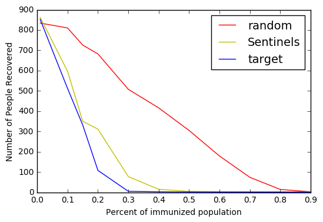

```python
plt.plot( *zip(*sorted(results.items())), *zip(*sorted(resultsSent.items())), *zip(*sorted(results2.items())))
plt.legend([ 'random', 'Sentinels', 'target'], fontsize=14, loc="upper right")
plt.xlabel("Percent of immunized population")
plt.ylabel("Number of People Recovered")
plt.show()
```

# Ex 3.3

```python
class SIRfriendsBeet:
    def __init__(self, g, r, seedout, seedtot, beta, mu):
        self.g = g
        self.beta = beta
        self.mu = mu
        self.r = r
        self.seedtot=seedtot
        self.seedsub=seedout
    def run(self, seed=[], num_steps = 1):

        numbertovacc=int(self.r*len(self.seedsub))

        vaccinated = self.seedtot[0:numbertovacc]
        if len(seed) == 0:
                seed = [np.random.choice(list(set(self.g.nodes()).difference(vaccinated)))]

                I_set = set(seed)
                S_set = set(self.g.nodes()).difference(I_set)
                R_set = set()

                t = 0

                StoI = set(seed)
                ItoR = set()

                while len(I_set) > 0:

                    for i in I_set.copy():
                        for s in set(self.g.neighbors(i)).difference(vaccinated).intersection(S_set).copy():
                            if np.random.uniform() < self.beta :
                                S_set.remove(s)
                                I_set.add(s)
                                StoI.add(s)


                        if np.random.uniform() < self.mu:
                            I_set.remove(i)
                            R_set.add(i)
                            ItoR.add(i)


                t += 1
                if t % num_steps == 0 or len(I_set) == 0:
                    yield({'t': t, 'S':S_set, 'I':I_set, 'R':R_set, 'StoI':StoI, 'ItoR':ItoR})
```

```python
seedsub=[]
perc=0.1
newlen= int(len(g.nodes())*perc) #% of nodes that i know
seedsub1 = list(np.random.choice(g.nodes(), newlen, replace=False) )
subdic={}
dd=[]
for i in seedsub1 :
                subdic[i]=g.neighbors(i)
                dd.append(g.neighbors(i))
vicino= [item for k in list(subdic.values()) for item in k ]
seedsub=seedsub1+ list(set(vicino))
subb=g.subgraph(seedsub)
a=sorted(nx.betweenness_centrality(subb).items(), key= lambda x: x[1], reverse=True)
a1=[(i[0])  for i in a if i[0] not in seedsub1]
```

Taking a random nodes in the subgraph, we can check that in the just built subgraph, the number of neighbors is smaller than the number of neighbors of the total graph.

```python
print(len(g.neighbors(1)), len(subb.neighbors(1)))
```

```
50 29
```

```python
resultsFriendsCentr = {}
rvec=[0.1, 0.15, 0.2, 0.3, 0.4, 0.5, 0.6, 0.7, 0.8, 0.9]

for r1 in rvec:
        final_r = []

        for i in range(0,300):
            sir = SIRfriendsBeet(g, r=r1, seedout=seedsub1, seedtot=a1, beta = 0.2, mu = 0.2)
            res = [k for k in sir.run()]
            final_r.append(len(res[len(res)-1].get('R')))
        resultsFriendsCentr[r1*perc] =  np.mean(final_r)
```

```python
resultsFriendsCentr
```

```
{0.010000000000000002: 822.42333333333329,
 0.015: 828.59666666666669,
 0.020000000000000004: 827.73000000000002,
 0.03: 816.08333333333337,
 0.04000000000000001: 778.30333333333328,
 0.05: 731.91666666666663,
 0.06: 713.65666666666664,
 0.06999999999999999: 680.24333333333334,
 0.08000000000000002: 638.88999999999999,
 0.09000000000000001: 643.14333333333332}
```

To compare this result with the results of the other 3 procedures, I modified the percentual of vaccinesfor the other strategy in such a way that the number of vaccines is the same for the 4 strategy (newrvec).

```python
newrvec= [x * 0.1 for x in rvec]
```

```python
resultsRandom = {}
for r1 in newrvec:
        final_r = []

        for i in range(0,300):
            sir = SIRimm(g, r=r1, beta = 0.2, mu = 0.2)
            res = [k for k in sir.run()]
            final_r.append(len(res[len(res)-1].get('R')))
        resultsRandom[r1] =  np.mean(final_r)
```

```python
resultsVacc= {}
for r1 in newrvec:
        final_r = []

        for i in range(0,300):
            sir = SIRvacc(g, r=r1, beta = 0.2, mu = 0.2)
            res = [k for k in sir.run()]
            final_r.append(len(res[len(res)-1].get('R')))
        resultsVacc[r1] =  np.mean(final_r)
```

```python
resultsSent= {}
for r1 in newrvec:
        final_r = []

        for i in range(0,300):
            sir = SIRsent1(g, r1, list(sentnew.keys()), beta = 0.2, mu = 0.2)
            res = [k for k in sir.run()]
            final_r.append(len(res[len(res)-1].get('R')))
        resultsSent[r1] =  np.mean(final_r)
```

[figure not shown]

```python
plt.plot(*zip(*sorted(resultsVacc.items())), *zip(*sorted(resultsSent.items())), *zip(*sorted(resultsRandom.items())), *zip(*sorted(resultsFriendsCentr.items())))
plt.rc("axes", prop_cycle=(cycler("color", ['r','y','b', 'g', 'grey'])))
plt.xlabel("Percent of immunized population")
plt.ylabel("Number of People Recovered")
plt.legend(['Target Immuniz.','Sentinels Immuniz.', 'Random Immuniz.', 'Friends Immuniz.'], fontsize=12, loc="best")
plt.show()
```